# SVD Example: Image Compression

We can express any matrix $A \in \mathbb{R}^{m \times n}$ in a decomposed form as:

$A = U \Sigma V$

The matrices $U\in \mathbb{R}^{m \times n}$ and $V\in \mathbb{R}^{n \times n}$ are unitary. This means $U^T U = U U ^T = I$, and similarly for $V$.

The matrix $\Sigma \in \mathbb{R}^{n \times n}$ is a diagonal matrix whose elements are $\sigma_1 > \sigma_2 > ... > \sigma_n$. The convention of SVD is to list the singular values in descending order.

The rank of the matrix $A$ is the number of singular values greater than zero.

We can calcualte two different matrix norms from singular values as $||A||_{2}|| = \sigma_{1}$ and $||A||_{F} = \sqrt{\sigma_{1}^{2} + \sigma_{2}^{2} + ... + \sigma_{n}^{2}}$.

### *Relationship to eigenvalues*

For symmetric matrices $A$, we have $A A^T = U \Sigma V V^T \Sigma U^T$ $A^T A = V^T \Sigma U^T U \Sigma V $

Using the properties of unitary matrices, this gives us: $A A^T = U \Sigma^2 U^T$ $A^T A = V^T \Sigma^2 V $

Every matrix has an SVD. The singular values are uniquely determined. The vectors of $U$ and $V$ are determined up to a minus sign.

### Relationship to Image Compression

The SVD allows us to use low-rank approximations of $A$. That is to say, we try to represent $A$ with an approximation by leveraging our knowledge of singular values.

By its construction, the SVD can be written as a sum of rank-one matrices.

$A = U \Sigma V = \sum_{j=1}^{n} \sigma_j u_j v_j$

We note now, that the rank of $A$ is determined by the non-zero singular values, so the above can be written as

$A = U \Sigma V = \sum_{j=1}^{r} \sigma_j u_j v_j$, where $r$ is the rank of $A$, that is to say, $\sigma_{r+1}, \sigma_{r+2}, ... , \sigma_{n} = 0 $.

If we perform the above summation, we recover the exact matrix $A$. But we can have a low-rank approximation if we only sum up to $k$ terms. Let us call the reduced matrix $A_{k}$.

$A_k = U \Sigma V = \sum_{j=1}^{k} \sigma_j u_j v_j$. That is the best rank-k approximation of $A$ we can obtain.

We note the following $||A - A_{k}|| = \sigma_{k+1}$ (using the property of matrix norms above).

In the Frobenius norm, we have $||A-A_{k}||_F = \sqrt{\sigma_{k+1}^{2} + \sigma_{k+2}^{2} + ... + \sigma_{r}^2}$.

```python
import numpy as np
import cv2
import os
import matplotlib.pyplot as plt
%matplotlib inline
```

```python
data_path = "/Users/zeyadzaky/Documents/CodeBase/data";
image_path = os.path.join(data_path,"goldfish_2.jpeg");
print(image_path)
img = cv2.imread(image_path);
img = cv2.cvtColor(img, cv2.COLOR_BGR2RGB)
print("Image Dimensions: ", np.shape(img))
```

```
/Users/zeyadzaky/Documents/CodeBase/data/goldfish_2.jpeg
Image Dimensions:  (191, 264, 3)
```

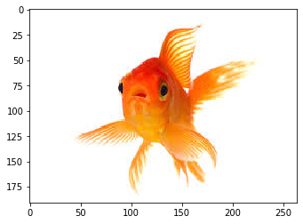

```python
plt.imshow(img)
```

```python
#Convert to Gray Scale
gray = cv2.cvtColor(img,cv2.COLOR_RGB2GRAY)
```

```
Image Dimensions:  (191, 264)
```

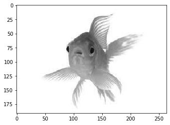

```python
plt.imshow(gray,cmap='gray')
print("Image Dimensions: ", np.shape(gray))
```

```python
#Now Perform SVD On Image
[u,s,v] = np.linalg.svd(gray)
print(np.shape(u))
print(np.shape(s))
print(np.shape(v))
```

```
(191, 191)
(191,)
(264, 264)
```

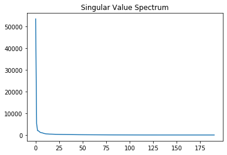

```python
#Plot the singular values
plt.plot(s)
plt.title("Singular Value Spectrum")
```

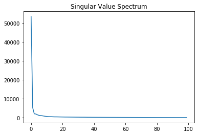

```python
plt.plot(s[:100])
plt.title("Singular Value Spectrum")
```

We can see by inspection that we can probably recreate the image using a small amount of singular values. Let us try and see what happens.

```python
k = 50;
uk = u[:,:k];
sk = np.diag(s[:k]);
vk = v[:k,:];
grayk = np.dot(uk, np.dot(sk,vk))
print(np.shape(grayk))
```

```
(191, 264)
```

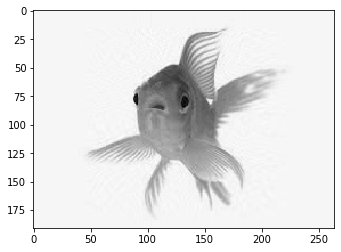

```python
plt.imshow(grayk,cmap='gray')
```

We can see that using only 50 terms of the singular values, we have gotten back an image that looks perceivably close to the original image. But how much did we save?

The original matrix $A$ has $m\times n$ numbers that we must keep. How many terms do we need to hold to reduce using SVD?

$U$ will hold $m \times k$ terms, $\Sigma$ will hold $k $ terms, and $V$ will hold $k\times n$ terms.

This means a total of $ mk + k + kn = k(m+n+1)$ terms. As long as $k(m+n+1) < mn$, we have saved in terms of number of elements to keep track of.

Can we estimate mathematically how many singular values to keep to achieve a certain tolerance? Instead of just guessing how many singular values we need? Yes. We can estimate how many singular values we need to recover some fraction of the original matrix.

We can take the norm of the approximation divided by the norm of the original matrix to obtain the fraction $\eta_F = \frac{||A_{k}||_{F}}{||A||_{F}}$. We can also use the 2-norm as $\eta_2 = \frac{||A_{k}||_{2}}{||A||_{2}}$

$||A||_{f} = \sqrt{ \sum{\sigma_{i}^{2}}}$

Therefore, our fraction above can be written as $\eta = \frac{\sigma_{0}^{2} + \sigma_{1}^{2} + ... + \sigma_{k}^{2}}{\sigma_{0}^{2} + \sigma_{1}^{2} + ... + \sigma_{n}^{2}}$

Now if we set $\eta$ to a value of our choosing, we can figure out exactly how many singular values we need to keep.

```python
#Set eta as we wish
eta = 0.9999;

#Get squared sum of all singular values for denominator
s2 = s*s;
den = np.sum(s2)
conv = 0;
k = 1;
while (conv==0):
    eta_F = np.sum(s[:k]*s[:k])/den;
    if (eta_F >= eta):
        conv = 1;
        print("Chosen k is: ",k);
    k = k+1;
```

```
Chosen k is:  49
```

```
(191, 264)
Number of Elements in Original Matrix:  50424
Number of Elements in Reduced SVD:  22800
Percent Savings:  54.78343645882913
```

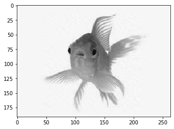

```python
uk = u[:,:k];
sk = np.diag(s[:k]);
vk = v[:k,:];
grayk = np.dot(uk, np.dot(sk,vk))
print(np.shape(grayk))
plt.imshow(grayk,cmap='gray')

m,n = np.shape(grayk);
print("Number of Elements in Original Matrix: ", m*n)
print("Number of Elements in Reduced SVD: ", k*(m+n+1))
print("Percent Savings: ", (1 - k*(m+n+1)/(m*n))*100)
```

### Conclusion

- We see we can use SVD to save memory
- Application of this is in image compression